# R-markdown-mtcars

Satvik Ahlawat, Rohit Mishra, Janhvee Awasthi

2025-02-17

## R Markdown Introduction

This report presents an exploratory analysis of the `mtcars` dataset Submited by Satvik Ahlawat(24221042) [Linkedin Profile](https://www.linkedin.com/in/satvikahlawat/), Rohit Mishra(24221139) [Linkedin Profile](https://www.linkedin.com/in/rohit-mishra-a6689031b/), Janhvee Awasthi(24221120) [Linkedin Profile](https://www.linkedin.com/in/janhvee-awasthi-378912239/), which contains 32 car models and their respective specifications, such as horsepower, fuel efficiency, weight, and transmission types. The goal of this study is to analyze different car attributes and provide business implications based on statistical insights.

# Data Dictionary

The `mtcars` dataset consists of 32 car models and their respective horsepower values (`hp`).

## Corrected Data Dictionary: Car Models & Horsepower

```r
# Creating a vector of Horsepower values
horsepower <- c(110, 110, 93, 110, 175, 105, 245, 62, 95, 123, 123, 180, 180, 180,
                205, 215, 230, 66, 52, 65, 97, 150, 150, 245, 175, 66, 91, 113,
                264, 175, 335, 109)

# Assigning car model names to the horsepower values
names(horsepower) <- c("Mazda RX4", "Mazda RX4 Wag", "Datsun 710", "Hornet 4 Drive",
                       "Hornet Sportabout", "Valiant", "Duster 360", "Merc 240D",
                       "Merc 230", "Merc 280", "Merc 280C", "Merc 450SE", "Merc 450SL",
                       "Merc 450SLC", "Cadillac Fleetwood", "Lincoln Continental",
                       "Chrysler Imperial", "Fiat 128", "Honda Civic", "Toyota Corolla",
                       "Toyota Corona", "Dodge Challenger", "AMC Javelin", "Camaro Z28",
                       "Pontiac Firebird", "Fiat X1-9", "Porsche 914-2", "Lotus Europa",
                       "Ford Pantera L", "Ferrari Dino", "Maserati Bora", "Volvo 142E")

# Printing the entire Horsepower Data Dictionary
print(horsepower)
```

```
##           Mazda RX4       Mazda RX4 Wag          Datsun 710      Hornet 4 Drive
##                 110                 110                  93                 110
##   Hornet Sportabout             Valiant          Duster 360           Merc 240D
##                 175                 105                 245                  62
##            Merc 230            Merc 280           Merc 280C          Merc 450SE
##                  95                 123                 123                 180
##          Merc 450SL         Merc 450SLC  Cadillac Fleetwood Lincoln Continental
##                 180                 180                 205                 215
##   Chrysler Imperial            Fiat 128         Honda Civic      Toyota Corolla
##                 230                  66                  52                  65
##       Toyota Corona    Dodge Challenger         AMC Javelin          Camaro Z28
##                  97                 150                 150                 245
##    Pontiac Firebird           Fiat X1-9       Porsche 914-2        Lotus Europa
##                 175                  66                  91                 113
##      Ford Pantera L        Ferrari Dino       Maserati Bora          Volvo 142E
##                 264                 175                 335                 109
```

```r
# Retrieving the horsepower of a specific car model
horsepower["Mazda RX4"]
```

```
## Mazda RX4
##       110
```

```r
horsepower["Ferrari Dino"]
```

```
## Ferrari Dino
##          175
```

```r
# Print structure of the dataset
str(horsepower)
```

```
##  Named num [1:32] 110 110 93 110 175 105 245 62 95 123 ...
##  - attr(*, "names")= chr [1:32] "Mazda RX4" "Mazda RX4 Wag" "Datsun 710" "Hornet 4 Drive" ...
```

1. Create an assigned task amongst features

```r
#a. Importing the dataset with proper variable names
data_dictionary <- data.frame(
  Column_Name = c("mpg", "cyl", "disp", "hp", "drat", "wt", "qsec", "vs", "am", "gear", "carb"),
  Description = c(
    "Miles per gallon (fuel efficiency)",
    "Number of cylinders",
    "Engine displacement (cubic inches)",
    "Horsepower",
    "Rear axle ratio",
    "Weight of the car (1000 lbs)",
    "1/4 mile time (acceleration)",
    "Engine type (0 = V-shaped, 1 = Straight)",
    "Transmission (0 = Automatic, 1 = Manual)",
    "Number of forward gears",
    "Number of carburetors"
  ),
  Data_Type = c("Numeric", "Integer", "Numeric", "Numeric", "Numeric", "Numeric", "Numeric", "Categorical", "Categorical", "Integer", "Integer")
)
print("Data Dictionary:")
```

```
## [1] "Data Dictionary:"
```

```r
print(data_dictionary)
```

```
##    Column_Name                              Description   Data_Type
## 1          mpg       Miles per gallon (fuel efficiency)     Numeric
## 2          cyl                      Number of cylinders     Integer
## 3         disp       Engine displacement (cubic inches)     Numeric
## 4           hp                               Horsepower     Numeric
## 5         drat                          Rear axle ratio     Numeric
## 6           wt             Weight of the car (1000 lbs)     Numeric
## 7         qsec             1/4 mile time (acceleration)     Numeric
## 8           vs Engine type (0 = V-shaped, 1 = Straight) Categorical
## 9           am Transmission (0 = Automatic, 1 = Manual) Categorical
## 10        gear                  Number of forward gears     Integer
## 11        carb                    Number of carburetors     Integer
```

```r
##summary
# B - summary of the mtcars
```

```r
summary(mtcars)
```

```
##       mpg             cyl             disp             hp
##  Min.   :10.40   Min.   :4.000   Min.   : 71.1   Min.   : 52.0
##  1st Qu.:15.43   1st Qu.:4.000   1st Qu.:120.8   1st Qu.: 96.5
##  Median :19.20   Median :6.000   Median :196.3   Median :123.0
##  Mean   :20.09   Mean   :6.188   Mean   :230.7   Mean   :146.7
##  3rd Qu.:22.80   3rd Qu.:8.000   3rd Qu.:326.0   3rd Qu.:180.0
##  Max.   :33.90   Max.   :8.000   Max.   :472.0   Max.   :335.0
##       drat             wt             qsec             vs
##  Min.   :2.760   Min.   :1.513   Min.   :14.50   Min.   :0.0000
##  1st Qu.:3.080   1st Qu.:2.581   1st Qu.:16.89   1st Qu.:0.0000
##  Median :3.695   Median :3.325   Median :17.71   Median :0.0000
##  Mean   :3.597   Mean   :3.217   Mean   :17.85   Mean   :0.4375
##  3rd Qu.:3.920   3rd Qu.:3.610   3rd Qu.:18.90   3rd Qu.:1.0000
##  Max.   :4.930   Max.   :5.424   Max.   :22.90   Max.   :1.0000
##        am              gear            carb
##  Min.   :0.0000   Min.   :3.000   Min.   :1.000
##  1st Qu.:0.0000   1st Qu.:3.000   1st Qu.:2.000
##  Median :0.0000   Median :4.000   Median :2.000
##  Mean   :0.4062   Mean   :3.688   Mean   :2.812
##  3rd Qu.:1.0000   3rd Qu.:4.000   3rd Qu.:4.000
##  Max.   :1.0000   Max.   :5.000   Max.   :8.000
```

#Data Visualization

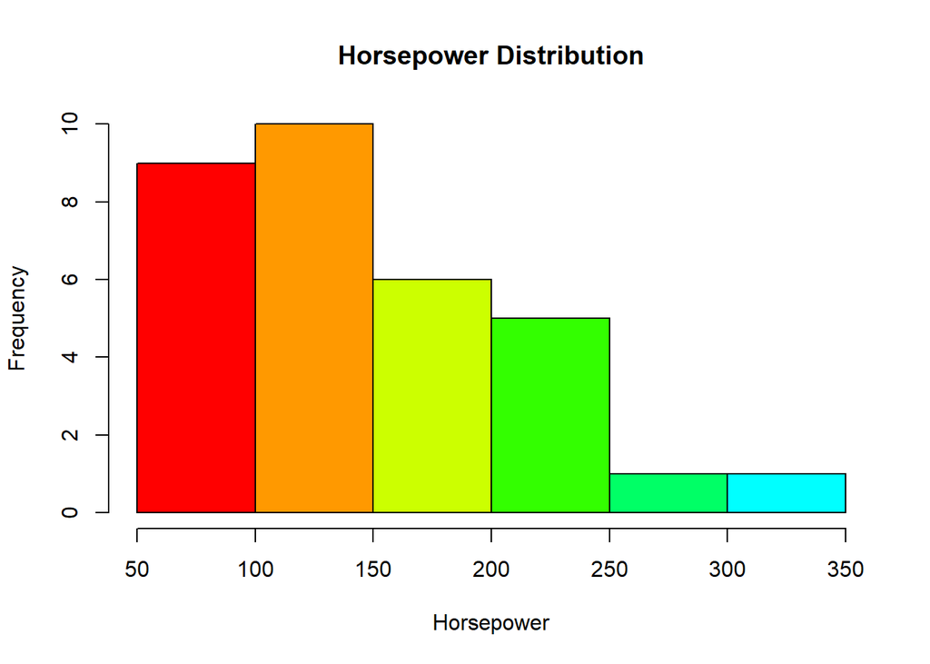

```r
# Load the built-in dataset
data(mtcars)
# Histogram of Horsepower (hp)
hist(mtcars$hp,
     col=rainbow(10),  # Generates colorful bars
     main="Horsepower Distribution",
     xlab="Horsepower",
     ylab="Frequency",
     border="black",
     breaks=10)
```

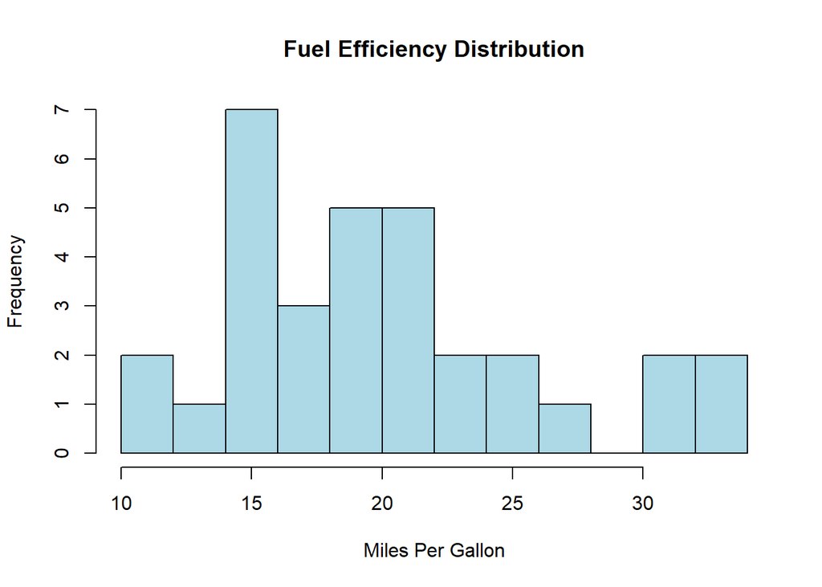

```r
# Histogram of Miles Per Gallon (mpg)
hist(mtcars$mpg,
     col="lightblue",  # Simple color
     main="Fuel Efficiency Distribution",
     xlab="Miles Per Gallon",
     ylab="Frequency",
     border="black",
     breaks=10)
```

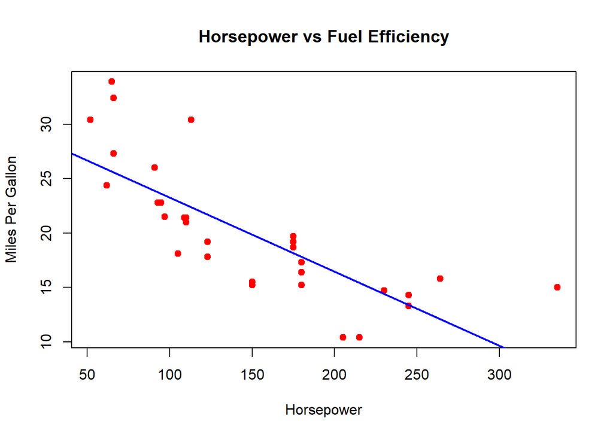

```r
# Scatter Plot of Horsepower (hp) vs Fuel Efficiency (mpg)
plot(mtcars$hp, mtcars$mpg,
     main="Horsepower vs Fuel Efficiency",
     xlab="Horsepower",
     ylab="Miles Per Gallon",
     col="red",
     pch=19)  # pch=19 gives solid dots

# Adding a simple trend line
abline(lm(mpg ~ hp, data=mtcars), col="blue", lwd=2)  # Linear regression line
```

# Business Implications

This section highlights the key business insights derived from the analysis of the mtcars dataset. These implications are important for automobile manufacturers, marketers, and consumers in making data-driven decisions.

## Fuel Efficiency vs Horsepower

Finding:  
- Cars with higher horsepower (hp) have lower fuel efficiency (mpg).  
- There is a negative correlation between horsepower and miles per gallon.

Implications for Business:  
- Car manufacturers should optimize powertrain efficiency to balance performance and fuel economy.  
- Marketing strategy should highlight fuel-efficient models for eco-conscious buyers.  
- Government regulations may impose higher taxes on fuel-inefficient vehicles, affecting pricing.

## Weight vs Performance

Finding:  
- Heavier cars (wt) tend to have lower mpg and slower acceleration (qsec).  
- Lighter cars generally have better fuel efficiency and faster acceleration.

Implications for Business:  
- Automobile companies should focus on lightweight materials (e.g., aluminum, carbon fiber) for fuel efficiency.  
- Performance car brands must balance weight reduction with safety and stability.  
- Government policies favoring lower emissions will push brands to develop hybrid/electric lightweight cars.

## Transmission Type: Manual vs Automatic

Finding:  
- Manual transmission (am = 1) cars generally have better fuel efficiency than automatic (am = 0) cars.  
- Automatic cars tend to be heavier and consume more fuel.

Implications for Business:  
- Luxury car brands should enhance automatic transmission efficiency (e.g., CVT, dual-clutch).  
- Car dealerships should educate customers on the trade-offs between automatic and manual transmission.  
- Sports car segment should continue offering manual transmissions for enthusiasts.

## Cylinder Count & Market Positioning

Finding:  
- Higher cylinder (cyl) count leads to increased power but reduced fuel economy.  
- 4-cylinder cars are the most fuel-efficient.  
- 8-cylinder cars dominate high-performance and luxury segments.

Implications for Business:  
- Mass-market car brands (Toyota, Honda) should focus on fuel-efficient 4-cylinder models.  
- Luxury & sports car brands (Ferrari, BMW, Audi) should cater to enthusiasts who prefer 6-8 cylinder performance cars.  
- EV (Electric Vehicle) manufacturers can use these insights to target high-performance EVs with battery optimization.

## Gear Count and Vehicle Efficiency

Implications for Business:  
- Manufacturers should focus on 6-speed+ transmissions for better efficiency and smoother driving experience.  
- High-performance brands should optimize gear ratios for acceleration and speed.  
- Hybrid & Electric Vehicles (EVs) should integrate advanced gear systems for power optimization.

## Conclusion

- The mtcars dataset provides valuable insights into automobile performance and efficiency.
- Car manufacturers can use this data to improve fuel efficiency, optimize performance, and enhance transmission systems.
- Consumers can make informed decisions on buying a car based on horsepower, fuel efficiency, and transmission type.
- Future innovations in lightweight materials, hybrid engines, and multi-gear transmissions will shape the automobile industry.